# 432 Class 21

Thomas E. Love, Ph.D.

2024-04-02

## Today’s Topic: Time-to-Event Data

- Back in Class 14, we discussed
  - Kaplan-Meier Estimation of the Survival Function
  - Creating Survival Objects, Drawing Survival Curves
  - Testing the difference between Survival Curves
- Today: start Cox Proportional Hazards Regression
  - The Hazard Function and its Estimation

See Chapters 29-31 of our Course Notes

## Setup

```r
knitr::opts_chunk$set(comment=NA)
options(width = 80)

library(janitor)
library(broom)
library(gt)
library(rms)
library(survival)
library(survminer)
library(tidyverse)

theme_set(theme_bw())
```

# A Simulated Example (`survex`)

## The `survex` example (from Class 14)

The `survex` data includes 1,000 subjects…

- `sub_id` = patient ID (1-1000)
- `age` = patient’s age at study entry, years
- `grp` = patient’s group (A or B)
- `study_yrs` = patient’s years of observed time in study until death or censoring
- `death` = 1 if patient died, 0 if censored.

To start, we’ll model a survival object `Surv(study_yrs, death)` using `grp`.

## The survex example

```r
survex <- read_csv("c21/data/survex.csv", show_col_types = FALSE) |>
  mutate(grp = factor(grp))

survex
```

```
# A tibble: 1,000 × 5
   sub_id   age grp   study_yrs death
    <dbl> <dbl> <fct>     <dbl> <dbl>
 1      1  60.6 B          3.10     1
 2      2  42.1 B          1.57     0
 3      3  54.9 B          3.24     0
 4      4  55.8 B         12.5      0
 5      5  52.5 A          3.25     0
 6      6  46.1 B          2.84     0
 7      7  61.2 B          6.06     1
 8      8  35.4 B         14.6      0
 9      9  59.9 B          5.03     1
10     10  75.4 A          3.25     0
# ℹ 990 more rows
```

## Create a survival object

```r
surv_obj <- Surv(time = survex$study_yrs,
                 event = survex$death)

head(surv_obj)
```

```
[1]  3.095   1.574+  3.239+ 12.496+  3.253+  2.837+
```

### Comparing Survival by Group

```r
km_grp <- survfit(surv_obj ~ survex$grp)

km_grp
```

```
Call: survfit(formula = surv_obj ~ survex$grp)

               n events median 0.95LCL 0.95UCL
survex$grp=A 380     90     NA      NA      NA
survex$grp=B 620     93     NA      NA      NA
```

## Kaplan-Meier Estimates

```r
summary(km_grp)
```

```
Call: survfit(formula = surv_obj ~ survex$grp)

                survex$grp=A
   time n.risk n.event survival std.err lower 95% CI upper 95% CI
  0.013    378       1    0.997 0.00264        0.992        1.000
  0.034    377       1    0.995 0.00373        0.987        1.000
  0.047    376       1    0.992 0.00456        0.983        1.000
  0.240    370       1    0.989 0.00528        0.979        1.000
  0.261    369       1    0.987 0.00591        0.975        0.998
  0.348    365       1    0.984 0.00648        0.971        0.997
  0.411    362       1    0.981 0.00701        0.968        0.995
  0.480    356       1    0.979 0.00751        0.964        0.993
  0.552    353       1    0.976 0.00799        0.960        0.992
  0.611    350       1    0.973 0.00844        0.957        0.990
  0.641    348       1    0.970 0.00886        0.953        0.988
  0.789    343       1    0.967 0.00928        0.949        0.986
  0.797    342       1    0.965 0.00967        0.946        0.984
  1.088    331       1    0.962 0.01007        0.942        0.982
  1.116    330       1    0.959 0.01045        0.938        0.979
  1.118    329       1    0.956 0.01082        0.935        0.977
  1.133    328       1    0.953 0.01117        0.931        0.975
  1.154    326       1    0.950 0.01152        0.928        0.973
  1.242    322       1    0.947 0.01185        0.924        0.970
  1.264    321       1    0.944 0.01218        0.920        0.968
  1.268    320       1    0.941 0.01249        0.917        0.966
  1.295    319       1    0.938 0.01280        0.913        0.964
  1.312    317       1    0.935 0.01309        0.910        0.961
  1.468    311       1    0.932 0.01339        0.906        0.959
  1.479    310       1    0.929 0.01368        0.903        0.956
  1.578    306       1    0.926 0.01397        0.899        0.954
  1.690    303       1    0.923 0.01425        0.896        0.951
  1.739    301       1    0.920 0.01453        0.892        0.949
  1.742    300       1    0.917 0.01480        0.888        0.946
  1.795    297       1    0.914 0.01507        0.885        0.944
  1.846    295       1    0.911 0.01534        0.881        0.941
  1.871    294       1    0.908 0.01559        0.878        0.939
  1.952    289       1    0.905 0.01585        0.874        0.936
  2.001    286       1    0.901 0.01611        0.870        0.933
  2.284    280       1    0.898 0.01637        0.867        0.931
  2.313    278       1    0.895 0.01663        0.863        0.928
```

[output cut: 132 more lines]

```
  6.962    279       1    0.827 0.01811        0.792        0.863
  7.215    266       1    0.824 0.01831        0.788        0.860
  7.231    265       1    0.820 0.01850        0.785        0.858
  7.236    264       1    0.817 0.01869        0.782        0.855
  7.505    254       1    0.814 0.01889        0.778        0.852
  7.823    248       1    0.811 0.01910        0.774        0.849
  7.840    246       1    0.808 0.01931        0.771        0.846
  8.465    222       1    0.804 0.01956        0.767        0.843
 10.244    167       1    0.799 0.02003        0.761        0.839
 11.318    133       1    0.793 0.02076        0.753        0.835
 11.511    126       1    0.787 0.02153        0.746        0.830
 11.643    120       1    0.780 0.02232        0.738        0.825
 12.143     98       1    0.772 0.02347        0.728        0.820
 13.502     47       1    0.756 0.02814        0.703        0.813
 13.746     37       1    0.735 0.03400        0.672        0.805
```

## Plotting the K-M Curves

```r
ggsurvplot(km_grp, data = survex)
```

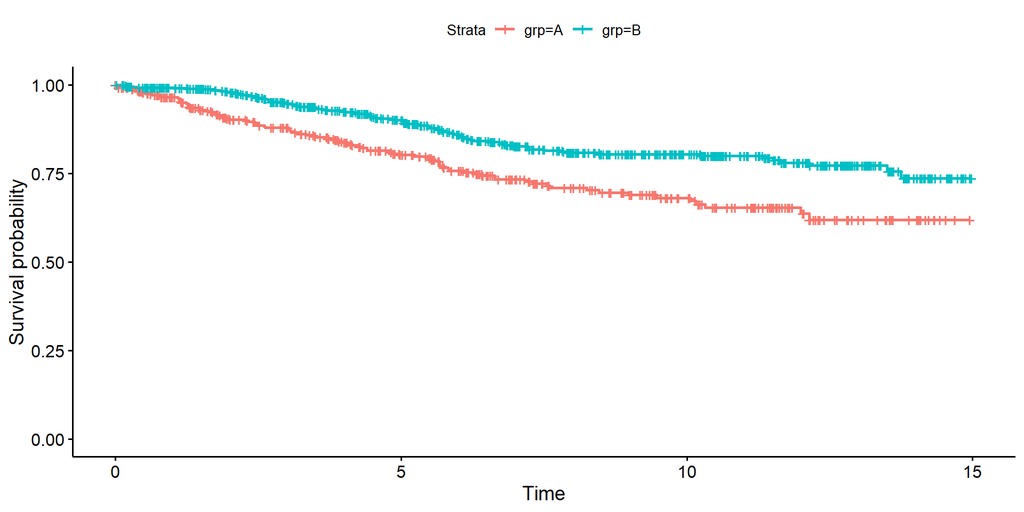

## Comparing Survival by group

This is the log rank test.

```r
survdiff(surv_obj ~ survex$grp)
```

```
Call:
survdiff(formula = surv_obj ~ survex$grp)

               N Observed Expected (O-E)^2/E (O-E)^2/V
survex$grp=A 380       90     62.7     11.85      18.1
survex$grp=B 620       93    120.3      6.18      18.1

 Chisq= 18.1  on 1 degrees of freedom, p= 2e-05
```

## Log - Log plot of K-M estimation

The two curves do not meet during the observation period, indicating the satisfaction of the proportional hazard assumption made by the log rank test.

```r
plot(survfit(surv_obj ~ grp, data = survex), fun = "cloglog")
```

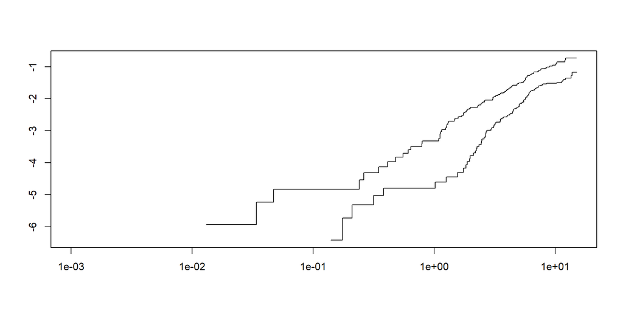

## Cumulative Event Rate for `km_grp`

- Add fun = “event” to our `ggsurvplot`…

```r
ggsurvplot(km_grp, data = survex, fun = "event",
           xlab = "Time in years", break.time.by = 2,
           risk.table = TRUE, risk.table.height = 0.25)
```

## Cumulative Event Rate for `km_grp`

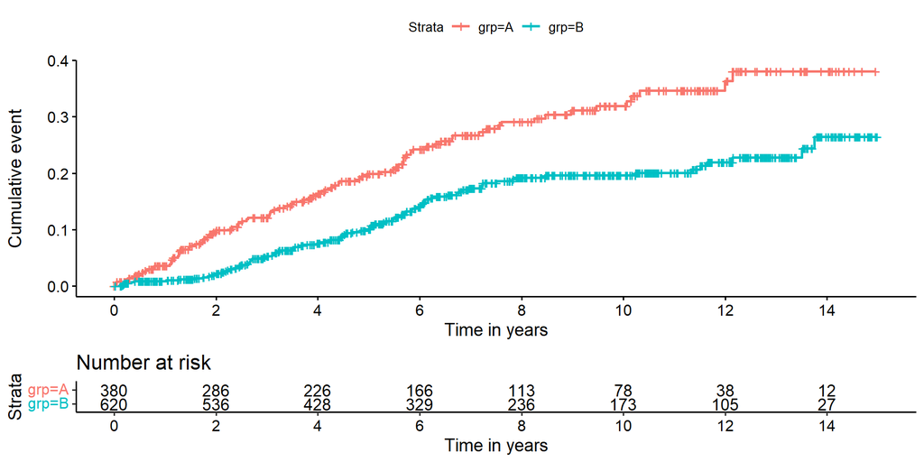

# The Hazard Function

## The Hazard Function

To build regression models for time-to-event data, we will need to introduce the *hazard function*, $H(t)$.

- Note that $H(t)$ = $-ln(S(t))$.

## Importance of the Hazard Function

The function $H(t)$ is an important analytic tool.

- It is used to describe the concept of the risk of “failure” in an interval after time $t$, conditioned on the subject having survived to time $t$.
- $H(t)$ is often called the *cumulative hazard function*, to emphasize the fact that its value is the “sum” of the hazard up to time $t$.

## Understanding the Hazard Function

Consider a subject in the `survex` study who has a survival time of 4 years.

- For this subject to die at 4 years, they had to survive for the first 3 years.
- The subject’s hazard at 4 years is the failure rate “per year” conditional on the subject being alive through the first 3 years.

Let’s ignore the group information for a moment.

## Estimating the Hazard Function

Suppose we want to estimate $H(t)$ across all subjects. There are several different methods, but we’ll focus on the inverse Kaplan-Meier estimator.

I’ll create something called `H.est1`, the inverse K-M estimate…

```r
Haz1.almost <- -log(km1$surv)
H_est1 <- c(Haz1.almost, tail(Haz1.almost, 1))
```

## Tibble of times and hazard estimates

```r
haz_frame <- tibble(
    time = c(km1$time, tail(km1$time, 1)),
    inverse_KM = H_est1)

haz_frame
```

```
# A tibble: 967 × 2
    time inverse_KM
   <dbl>      <dbl>
 1 0.001    0
 2 0.013    0.00100
 3 0.018    0.00100
 4 0.02     0.00100
 5 0.034    0.00201
 6 0.047    0.00301
 7 0.059    0.00301
 8 0.114    0.00301
 9 0.121    0.00301
10 0.135    0.00301
# ℹ 957 more rows
```

## Cumulative Hazard Function from Inverse Kaplan-Meier

```r
ggplot(haz_frame, aes(x = time, y = inverse_KM)) +
    geom_step() +
    scale_x_continuous(breaks = c(0, 3, 6, 9, 12, 15)) +
    labs(x = "Years of Follow-Up",
         y = "Cumulative Hazard of Death",
         title = "Cumulative Hazard Function via Inverse K-M")
```

## Cumulative Hazard Function from Inverse Kaplan-Meier

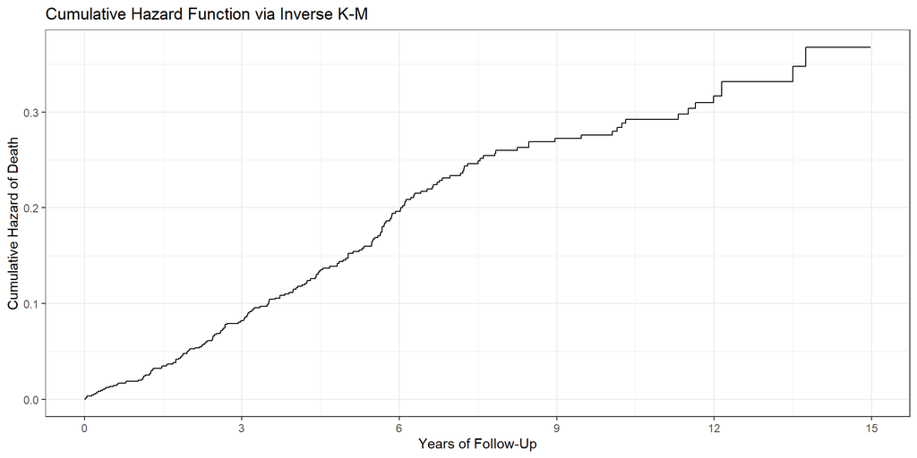

## Cumulative Hazard Plot via `ggsurvplot`

```r
ggsurvplot(km1, data = survex, fun = "cumhaz",
           conf.int = FALSE,
           xlab = "Years of Follow-Up",
           break.time.by = 3,
           risk.table = FALSE)
```

## Cumulative Hazard Plot via `ggsurvplot`

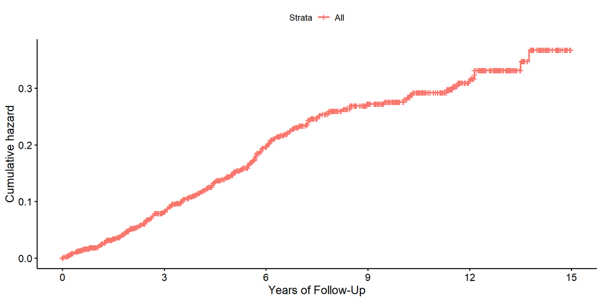

## Plotting the Cumulative Hazard Function by Group

For our `km_grp` fit, we’d use something like this…

```r
ggsurvplot(km_grp, data = survex, fun = "cumhaz",
           xlab = "Time in years",
           pval = TRUE,
           break.time.by = 2,
           risk.table = TRUE,
           risk.table.height = 0.25)
```

## Plotting the Cumulative Hazard Function by Group

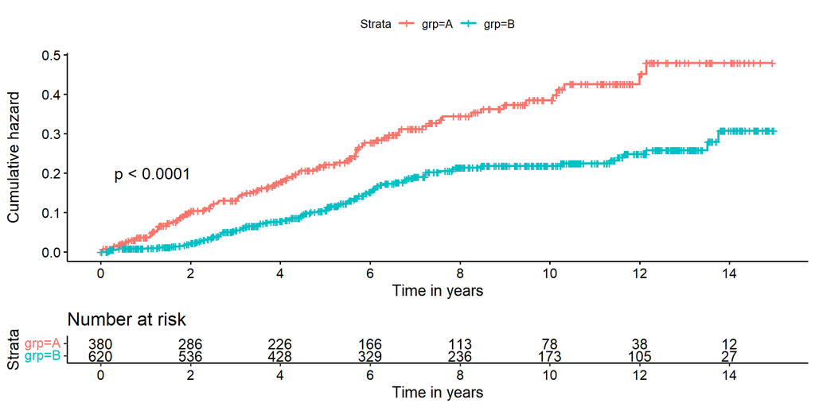

# Fitting a Cox Proportional Hazards Regression

## Cox Proportional Hazards Regression

```r
mod_grp <- coxph(Surv(study_yrs, death) ~ grp, data = survex)
```

The Cox proportional hazards model fits survival data with a constant (not varying over time) covariate (here, `grp`) to a hazard function of the form:

$$h(t|grp) = h_0(t) exp(\beta_1grp)$$

where we estimate the unknown value of $\beta_1$ and where $h_0(t)$ is the baseline hazard which depends on $t$ but not on `grp`.

## Coefficients of our Cox model

```r
mod_grp
```

```
Call:
coxph(formula = Surv(study_yrs, death) ~ grp, data = survex)

        coef exp(coef) se(coef)      z        p
grpB -0.6195    0.5382   0.1481 -4.184 2.86e-05

Likelihood ratio test=17.18  on 1 df, p=3.399e-05
n= 1000, number of events= 183
```

Our hazard ratio estimate is 0.5382 for group B (vs. A)

- Hazard Ratio < 1 indicates a decrease in hazard for subjects in group B as compared to those in group A.
- Does this match our plot?

## What if we also include Age?

```r
survex$S <- Surv(survex$study_yrs, survex$death)

mod_age_grp <- coxph(S ~ grp + age, data = survex)

mod_age_grp
```

```
Call:
coxph(formula = S ~ grp + age, data = survex)

          coef exp(coef)  se(coef)      z        p
grpB -0.597528  0.550170  0.148207 -4.032 5.54e-05
age   0.041920  1.042811  0.005571  7.525 5.26e-14

Likelihood ratio test=69.93  on 2 df, p=6.522e-16
n= 1000, number of events= 183
```

## Tidied coefficients: Age + Group model

```r
tidy(mod_age_grp, exponentiate = TRUE, conf.int = T) |>
    gt() |> fmt_number(decimals = 3) |> tab_options(table.font.size = 20)
```

| term | estimate | std.error | statistic | p.value | conf.low | conf.high |
| --- | --- | --- | --- | --- | --- | --- |
| grpB | 0.550 | 0.148 | −4.032 | 0.000 | 0.411 | 0.736 |
| age | 1.043 | 0.006 | 7.525 | 0.000 | 1.031 | 1.054 |

- If Harry is a year older than Steve and both are in the same group, Harry’s hazard of death is 1.04 times that of Steve.
- If Harry (group B) and Sally (group A) are the same age, then Harry’s hazard of death is 0.55 times that of Sally.

## `glance` for this `coxph` model?

```r
glance(mod_age_grp) |> select(3:10) |>
  gt() |> tab_options(table.font.size = 20) |>
  fmt_number(decimals = 3)
```

| statistic.log | p.value.log | statistic.sc | p.value.sc | statistic.wald | p.value.wald | statistic.robust | p.value.robust |
| --- | --- | --- | --- | --- | --- | --- | --- |
| 69.932 | 0.000 | 73.331 | 0.000 | 75.830 | 0.000 | NA | NA |

```r
glance(mod_age_grp) |> select(15:18) |>
  gt() |> tab_options(table.font.size = 20) |>
  fmt_number(columns = -nobs, decimals = 2)
```

| logLik | AIC | BIC | nobs |
| --- | --- | --- | --- |
| −1,132.83 | 2,269.67 | 2,276.08 | 1000 |

We see results from log rank, score and Wald tests, as well as the AIC and BIC. But that’s not all we can get from `glance()` with a Cox model…

## Concordance and $R^2$

```r
glance(mod_age_grp) |> select(c(1:2, 11:14)) |>
  gt() |> tab_options(table.font.size = 20) |>
  fmt_number(columns = r.squared:std.error.concordance, decimals = 3)
```

| n | nevent | r.squared | r.squared.max | concordance | std.error.concordance |
| --- | --- | --- | --- | --- | --- |
| 1000 | 183 | 0.068 | 0.903 | 0.688 | 0.020 |

The `concordance` is a goodness-of-fit measure. It describes the probability that the prediction goes in the same direction as the actual data (the fraction of concordant pairs between predictions and the data.) `glance` also provides a standard error for `concordance`.

We also get a Cox-Snell $R^2$ along with its maximum value (< 1.)

## Impact of adding `age` to `group`?

```r
anova(mod_age_grp, mod_grp)
```

[output not shown]

```r
AIC(mod_age_grp, mod_grp)
```

```
            df      AIC
mod_age_grp  2 2269.666
mod_grp      1 2320.418
```

```r
BIC(mod_age_grp, mod_grp)
```

```
            df      BIC
mod_age_grp  2 2276.085
mod_grp      1 2323.627
```

## Checking the Proportional Hazards Assumption

If the proportional hazards assumption is appropriate, we should see a slope of essentially zero in the residuals that are plotted against time on the next slide.

- If we see a slope that seriously different from zero, that will suggest a violation of the proportional hazards assumption.
- A hypothesis test is also performed, where a small *p* value indicates a potential problem with the assumption.

## Plot to Check Proportional Hazards

```r
ggcoxzph(cox.zph(mod_age_grp))
```

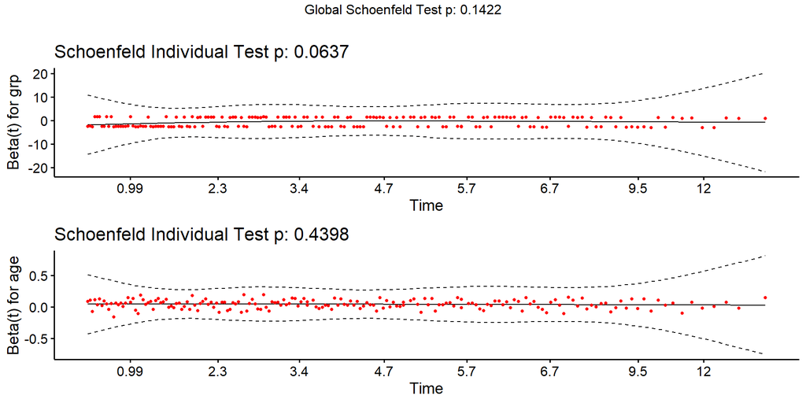

## What happens if we see a violation?

We could add a non-linear predictor term or use a different kind of survival model.

- If the PH assumption fails on a categorical predictor, fit a Cox model stratified by that predictor (use `strata(var)` rather than `var` in the specification of the `coxph` model.)
- If the PH assumption is violated, this means the hazard isn’t constant over time, so we could fit separate Cox models for a series of time intervals.

## If we see a violation…

Another option would be to use an extension of the Cox model that permits covariates to vary over time.

Visit https://cran.r-project.org/web/packages/survival/vignettes/timedep.pdf for details on building the relevant data sets and models, with examples.

# A Real Data Example

## The `brca` trial

The `brca` data<sup>1</sup> describes a parallel randomized trial of three treatments, adjuvant to surgery in subjects with stage-2 carcinoma of the breast.

- `S_CT` = Surgery plus one year of chemotherapy
- `S_IT` = Surgery plus one year of immunotherapy
- `S_Both` = Surgery plus one year of chemotherapy and immunotherapy
[^1]: Chen and Peace (2011) *Clinical Trial Data Analysis Using R*, Section 5.1

## Variables in our `brca` data

The measure of efficacy was “time to death” in weeks.

In addition to `treat`, our variables are:

- `trial_weeks`: time in the study, in weeks, to death or censoring
- `last_alive`: 1 if alive at last follow-up (and thus censored), 0 if dead
- `age`: age in years at the start of the trial

## Ingesting the `brca` data

```r
brca <- read_csv("c21/data/brca.csv", show_col_types = FALSE) |>
    mutate(across(where(is_character), as_factor),
           subject = as.character(subject))
```

This is a typical right-censored survival data set with interest in the comparative analysis of the three treatments.

1. Does immunotherapy added to surgery plus chemotherapy improve survival? (Comparing `S_Both` to `S_CT`)
2. Does chemotherapy add efficacy to surgery plus immunotherapy? (`S_Both` vs. `S_IT`)
3. What is the effect of `age` on survival?

## The `brca` data (big problem: n = 31!)

```r
brca
```

```
# A tibble: 31 × 5
   subject treat  trial_weeks last_alive   age
   <chr>   <fct>        <dbl>      <dbl> <dbl>
 1 A01     S_CT           102          0    55
 2 A02     S_IT           192          0    62
 3 A03     S_Both          73          0    72
 4 A04     S_CT            58          1    48
 5 A05     S_CT            48          1    26
 6 A06     S_IT           182          1    52
 7 A07     S_IT           196          1    50
 8 A08     S_CT           177          1    49
 9 A09     S_IT           191          1    62
10 A10     S_Both          36          0    60
# ℹ 21 more rows
```

## Create survival object

- `trial_weeks`: time in the study, in weeks, to death or censoring
- `last_alive`: 1 if alive at last follow-up (and thus censored), 0 if dead

So `last_alive` = 0 if the event (death) occurs.

```r
brca$S <- with(brca, Surv(trial_weeks, last_alive == 0))

head(brca$S)
```

```
[1] 102  192   73   58+  48+ 182+
```

## Build Kaplan-Meier Estimator

```r
kmfit <- survfit(S ~ treat, dat = brca)

print(kmfit, print.rmean = TRUE)
```

```
Call: survfit(formula = S ~ treat, data = brca)

              n events rmean* se(rmean) median 0.95LCL 0.95UCL
treat=S_CT   11      6    153      21.1    144     102      NA
treat=S_IT   10      5    192      19.3    192     144      NA
treat=S_Both 10      4    193      25.0     NA     139      NA
    * restricted mean with upper limit =  251
```

## The Kaplan-Meier estimates

```r
summary(kmfit)
```

```
Call: survfit(formula = S ~ treat, data = brca)

                treat=S_CT
 time n.risk n.event survival std.err lower 95% CI upper 95% CI
   55     10       1    0.900  0.0949        0.732        1.000
   63      8       1    0.787  0.1340        0.564        1.000
  102      7       1    0.675  0.1551        0.430        1.000
  133      6       1    0.562  0.1651        0.316        1.000
  144      5       1    0.450  0.1660        0.218        0.927
  217      1       1    0.000     NaN           NA           NA

                treat=S_IT
 time n.risk n.event survival std.err lower 95% CI upper 95% CI
  102     10       1     0.90  0.0949        0.732        1.000
  105      9       1     0.80  0.1265        0.587        1.000
  144      8       1     0.70  0.1449        0.467        1.000
  151      7       1     0.60  0.1549        0.362        0.995
  192      4       1     0.45  0.1743        0.211        0.961

                treat=S_Both
 time n.risk n.event survival std.err lower 95% CI upper 95% CI
   36     10       1    0.900  0.0949        0.732            1
   73      9       1    0.800  0.1265        0.587            1
  139      8       1    0.700  0.1449        0.467            1
  185      6       1    0.583  0.1610        0.340            1
```

## K-M Plot via `survminer`

```r
ggsurvplot(kmfit, data = brca, risk.table = TRUE,
           risk.table.height = 0.25, xlab = "Time in weeks")
```

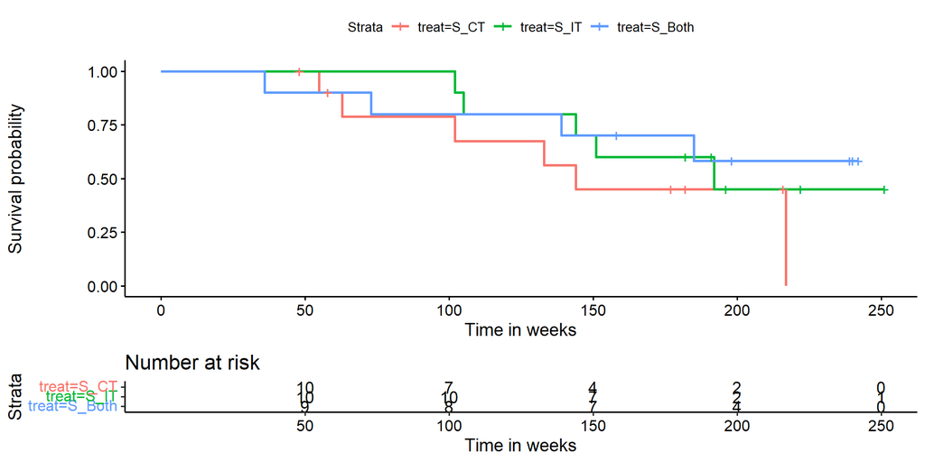

## Testing the difference between curves

```r
survdiff(S ~ treat, dat = brca)
```

```
Call:
survdiff(formula = S ~ treat, data = brca)

              N Observed Expected (O-E)^2/E (O-E)^2/V
treat=S_CT   11        6     3.80    1.2772    1.7647
treat=S_IT   10        5     5.58    0.0605    0.0981
treat=S_Both 10        4     5.62    0.4676    0.7725

 Chisq= 1.9  on 2 degrees of freedom, p= 0.4
```

What do we conclude?

## Log - Log plot to check PH assumption

Do we satisfy the proportional hazard assumption made by the log rank test? Do these lines for treatments cross?

```r
plot(survfit(S ~ treat, data = brca), fun = "cloglog")
```

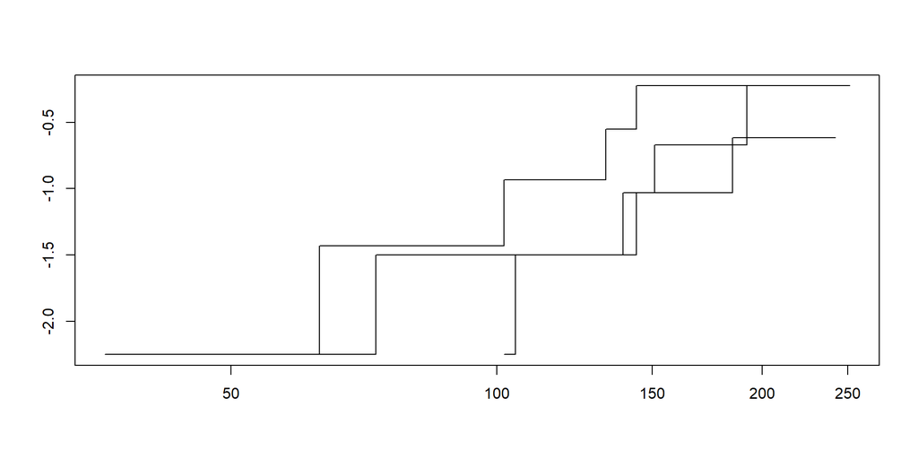

# A Cox Model for Treatment

## Fit Cox Model `mod_T`: Treatment alone

```r
mod_T <- coxph(S ~ treat, data = brca)
mod_T
```

```
Call:
coxph(formula = S ~ treat, data = brca)

               coef exp(coef) se(coef)      z     p
treatS_IT   -0.5832    0.5581   0.6088 -0.958 0.338
treatS_Both -0.8313    0.4355   0.6547 -1.270 0.204

Likelihood ratio test=1.75  on 2 df, p=0.4164
n= 31, number of events= 15
```

## Impact of Treatment on Survival

```r
summary(mod_T)
```

```
Call:
coxph(formula = S ~ treat, data = brca)

  n= 31, number of events= 15

               coef exp(coef) se(coef)      z Pr(>|z|)
treatS_IT   -0.5832    0.5581   0.6088 -0.958    0.338
treatS_Both -0.8313    0.4355   0.6547 -1.270    0.204

            exp(coef) exp(-coef) lower .95 upper .95
treatS_IT      0.5581      1.792    0.1692     1.840
treatS_Both    0.4355      2.296    0.1207     1.571

Concordance= 0.577  (se = 0.083 )
Likelihood ratio test= 1.75  on 2 df,   p=0.4
Wald test            = 1.82  on 2 df,   p=0.4
Score (logrank) test = 1.89  on 2 df,   p=0.4
```

## Interpreting the Summaries

```r
tidy(mod_T, exponentiate = TRUE, conf.int = TRUE) |>
    gt() |> fmt_number(decimals = 3) |> tab_options(table.font.size = 20)
```

| term | estimate | std.error | statistic | p.value | conf.low | conf.high |
| --- | --- | --- | --- | --- | --- | --- |
| treatS_IT | 0.558 | 0.609 | −0.958 | 0.338 | 0.169 | 1.840 |
| treatS_Both | 0.435 | 0.655 | −1.270 | 0.204 | 0.121 | 1.571 |

- A subject treated with `S_IT` is estimated to have 0.558 times the hazard (95% CI: 0.169, 1.840) of a subject treated with `S_CT` (the baseline).
- A subject treated with `S_Both` is estimated to have 0.435 times the hazard (95% CI 0.121, 1.571) of a subject treated with `S_CT`.

## Forest Plot for Treatment model

```r
ggforest(mod_T, data = brca)
```

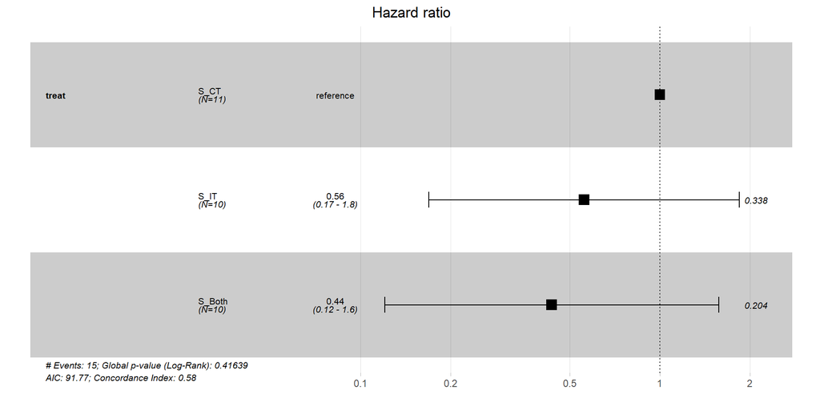

## `glance(mod_T)` Fit Summaries

```r
glance(mod_T) |> select(1:8) |> gt() |>
  fmt_number(columns = 3:8, decimals = 3) |>
  tab_options(table.font.size = 24)
```

| n | nevent | statistic.log | p.value.log | statistic.sc | p.value.sc | statistic.wald | p.value.wald |
| --- | --- | --- | --- | --- | --- | --- | --- |
| 31 | 15 | 1.752 | 0.416 | 1.895 | 0.388 | 1.820 | 0.403 |

shows the first eight columns.

Below we show the other eight useful columns for 432.

```r
glance(mod_T) |> select(11:18) |> gt() |>
  fmt_number(columns = 1:7, decimals = 3) |>
  tab_options(table.font.size = 24)
```

| r.squared | r.squared.max | concordance | std.error.concordance | logLik | AIC | BIC | nobs |
| --- | --- | --- | --- | --- | --- | --- | --- |
| 0.055 | 0.944 | 0.577 | 0.083 | −43.886 | 91.773 | 93.189 | 31 |

## Summing up `glance(mod_T)`

| n | nevent | statistic.log | p.value.log | statistic.sc | p.value.sc | statistic.wald | p.value.wald |
| --- | --- | --- | --- | --- | --- | --- | --- |
| 31 | 15 | 1.752 | 0.416 | 1.895 | 0.388 | 1.820 | 0.403 |

- `n` = 31 cases, with `nevent` = 15 events (so 16 censored)
- log rank test statistic = 1.752, *p* = 0.416
- Score test statistic = 1.895, *p* = 0.388
- Wald test statistic = 1.820, *p* = 0.403
  - Each tests $H_0$: Treatment adds no value

## Summing up `glance(mod_T)`

| r.squared | r.squared.max | concordance | std.error.concordance | logLik | AIC | BIC | nobs |
| --- | --- | --- | --- | --- | --- | --- | --- |
| 0.055 | 0.944 | 0.577 | 0.083 | −43.886 | 91.773 | 93.189 | 31 |

- (Cox-Snell) R-Squared = 0.055, Maximum Pseudo R-Square = 0.944
  - Cox and Snell’s pseudo-$R^2$ reflects the improvement of this model over the model with the intercept alone, with higher values indicating more substantial improvement over an intercept-only model.
  - Not really a percentage of anything: often the maximum value here is less than 1.

## Summing up `glance(mod_T)`

- Concordance = 0.577 (standard error = 0.083)
  - Really only appropriate when we have at least one quantitative predictor in the Cox model
  - Assesses probability of agreement between survival time and the risk score generated by the predictors
  - 1 indicates perfect agreement, 0.5 indicates no better than chance
- log Likelihood = -43.886, AIC = 91.773, BIC = 93.189
  - Usual summaries, used to compare models, mostly

## Graphical PH Check for `mod_T`

```r
ggcoxzph(cox.zph(mod_T))
```

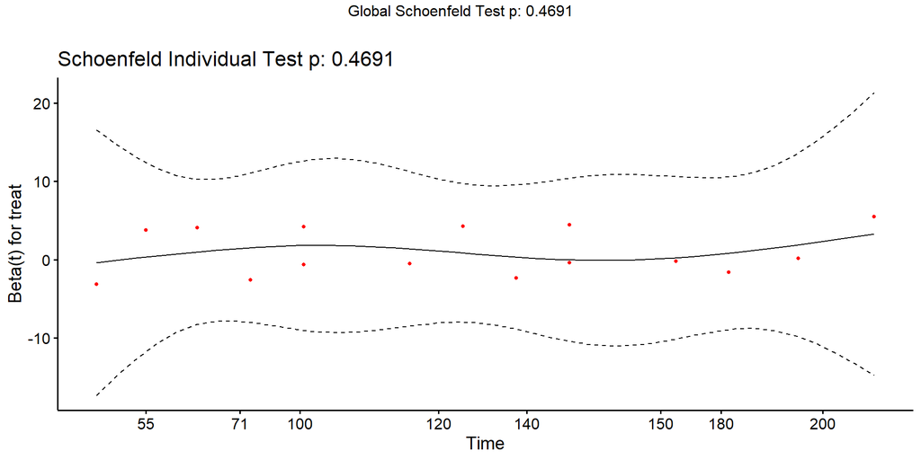

## Next Time

- Fitting more complex Cox models with `coxph` and `cph` (from `rms`) for the `brca` data
- Reviewing some key ideas from the American Statistical Association’s 2019 commentary on p values and statistical significance: “[Moving to a World Beyond p < 0.05](https://www.tandfonline.com/doi/full/10.1080/00031305.2019.1583913)”

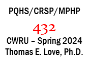

432 Class 21 | 2024-04-02 | https://thomaselove.github.io/432-2024/